# Risk Factor Analysis

## Outcome Variable

**Outcome Variable:** ever_wasted

## Predictor Variables

**Intervention Variable:** fhtcm

**Adjustment Set:**

- arm
- W_mage
- W_fage
- meducyrs
- feducyrs
- W_mhtcm
- W_mwtkg
- W_mbmi
- single
- delta_W_mage
- delta_W_fage
- delta_meducyrs
- delta_feducyrs
- delta_W_mhtcm
- delta_W_mwtkg
- delta_W_mbmi
- delta_single

## Stratifying Variables

The analysis was stratified on these variable(s):

- agecat
- studyid
- country

## Data Summary

| agecat | studyid | country | fhtcm | ever_wasted | n_cell | n |
| --- | --- | --- | --- | --- | --- | --- |
| 0-24 months | ki1000304b-SAS-CompFeed | INDIA | >=167 cm | 0 | 255 | 895 |
| 0-24 months | ki1000304b-SAS-CompFeed | INDIA | >=167 cm | 1 | 152 | 895 |
| 0-24 months | ki1000304b-SAS-CompFeed | INDIA | <162 cm | 0 | 130 | 895 |
| 0-24 months | ki1000304b-SAS-CompFeed | INDIA | <162 cm | 1 | 96 | 895 |
| 0-24 months | ki1000304b-SAS-CompFeed | INDIA | [162-167) cm | 0 | 145 | 895 |
| 0-24 months | ki1000304b-SAS-CompFeed | INDIA | [162-167) cm | 1 | 117 | 895 |
| 0-24 months | ki1000304b-SAS-FoodSuppl | INDIA | >=167 cm | 0 | 53 | 399 |
| 0-24 months | ki1000304b-SAS-FoodSuppl | INDIA | >=167 cm | 1 | 53 | 399 |
| 0-24 months | ki1000304b-SAS-FoodSuppl | INDIA | <162 cm | 0 | 75 | 399 |
| 0-24 months | ki1000304b-SAS-FoodSuppl | INDIA | <162 cm | 1 | 88 | 399 |
| 0-24 months | ki1000304b-SAS-FoodSuppl | INDIA | [162-167) cm | 0 | 83 | 399 |
| 0-24 months | ki1000304b-SAS-FoodSuppl | INDIA | [162-167) cm | 1 | 47 | 399 |
| 0-24 months | ki1101329-Keneba | GAMBIA | >=167 cm | 0 | 758 | 1933 |
| 0-24 months | ki1101329-Keneba | GAMBIA | >=167 cm | 1 | 490 | 1933 |
| 0-24 months | ki1101329-Keneba | GAMBIA | <162 cm | 0 | 80 | 1933 |
| 0-24 months | ki1101329-Keneba | GAMBIA | <162 cm | 1 | 52 | 1933 |
| 0-24 months | ki1101329-Keneba | GAMBIA | [162-167) cm | 0 | 324 | 1933 |
| 0-24 months | ki1101329-Keneba | GAMBIA | [162-167) cm | 1 | 229 | 1933 |
| 0-24 months | ki1119695-PROBIT | BELARUS | >=167 cm | 0 | 8471 | 12537 |
| 0-24 months | ki1119695-PROBIT | BELARUS | >=167 cm | 1 | 3273 | 12537 |
| 0-24 months | ki1119695-PROBIT | BELARUS | <162 cm | 0 | 121 | 12537 |
| 0-24 months | ki1119695-PROBIT | BELARUS | <162 cm | 1 | 47 | 12537 |
| 0-24 months | ki1119695-PROBIT | BELARUS | [162-167) cm | 0 | 444 | 12537 |
| 0-24 months | ki1119695-PROBIT | BELARUS | [162-167) cm | 1 | 181 | 12537 |
| 0-24 months | ki1135781-COHORTS | GUATEMALA | >=167 cm | 0 | 54 | 495 |
| 0-24 months | ki1135781-COHORTS | GUATEMALA | >=167 cm | 1 | 9 | 495 |
| 0-24 months | ki1135781-COHORTS | GUATEMALA | <162 cm | 0 | 224 | 495 |
| 0-24 months | ki1135781-COHORTS | GUATEMALA | <162 cm | 1 | 69 | 495 |
| 0-24 months | ki1135781-COHORTS | GUATEMALA | [162-167) cm | 0 | 105 | 495 |
| 0-24 months | ki1135781-COHORTS | GUATEMALA | [162-167) cm | 1 | 34 | 495 |

[output cut: 60 more lines]

The following strata were considered:

- agecat: 0-24 months, studyid: ki1000304b-SAS-CompFeed, country: INDIA
- agecat: 0-24 months, studyid: ki1000304b-SAS-FoodSuppl, country: INDIA
- agecat: 0-24 months, studyid: ki1101329-Keneba, country: GAMBIA
- agecat: 0-24 months, studyid: ki1119695-PROBIT, country: BELARUS
- agecat: 0-24 months, studyid: ki1135781-COHORTS, country: GUATEMALA
- agecat: 0-6 months, studyid: ki1000304b-SAS-CompFeed, country: INDIA
- agecat: 0-6 months, studyid: ki1000304b-SAS-FoodSuppl, country: INDIA
- agecat: 0-6 months, studyid: ki1101329-Keneba, country: GAMBIA
- agecat: 0-6 months, studyid: ki1119695-PROBIT, country: BELARUS
- agecat: 0-6 months, studyid: ki1135781-COHORTS, country: GUATEMALA
- agecat: 6-24 months, studyid: ki1000304b-SAS-CompFeed, country: INDIA
- agecat: 6-24 months, studyid: ki1000304b-SAS-FoodSuppl, country: INDIA
- agecat: 6-24 months, studyid: ki1101329-Keneba, country: GAMBIA
- agecat: 6-24 months, studyid: ki1119695-PROBIT, country: BELARUS
- agecat: 6-24 months, studyid: ki1135781-COHORTS, country: GUATEMALA

### Dropped Strata

Some strata were dropped due to rare outcomes:

- agecat: 0-6 months, studyid: ki1135781-COHORTS, country: GUATEMALA
- agecat: 6-24 months, studyid: ki1119695-PROBIT, country: BELARUS

## Methods Detail

We’re interested in the causal parameters $E[Y_a]$ for all values of $a \in \mathcal{A}$. These parameters represent the mean outcome if, possibly contrary to fact, we intervened to set all units to have $A=a$. Under the randomization and positivity assumptions, these are identified by the statistical parameters $\psi_a=E_W[E_{Y|A,W}(Y|A=a,W)]$. In addition, we’re interested in the mean of $Y$, $E[Y]$ under no intervention (the observed mean). We will estimate these parameters by using SuperLearner to fit the relevant likelihood factors – $E_{Y|A,W}(Y|A=a,W)$ and $p(A=a|W)$, and then updating our likelihood fit using a joint TMLE.

For unadjusted analyses ($W=\{\}$), initial likelihoods were estimated using Lrnr_glm to estimate the simple $E(Y|A)$ and Lrnr_mean to estimate $p(A)$. For adjusted analyses, a small library containing Lrnr_glmnet, Lrnr_xgboost, and Lrnr_mean was used.

Having estimated these parameters, we will then use the delta method to estimate relative risks and attributable risks relative to a prespecified baseline level of $A$.

# Results Detail

## Results Plots

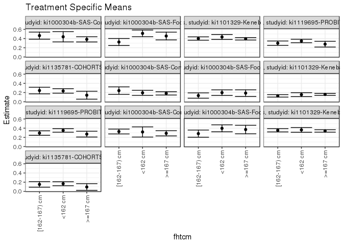

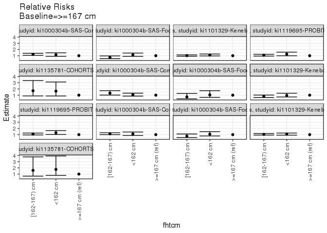

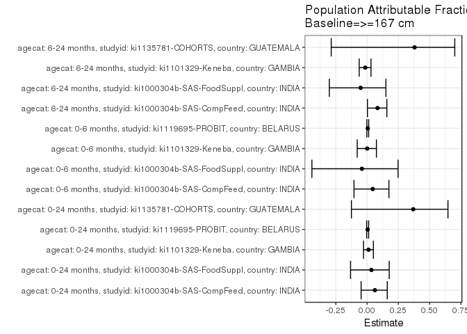

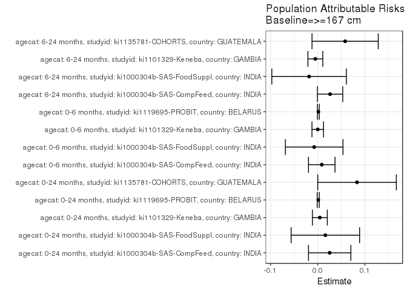

## Results Table

### Parameter: TSM

| agecat | studyid | country | intervention_level | baseline_level | estimate | ci_lower | ci_upper |
| --- | --- | --- | --- | --- | --- | --- | --- |
| 0-24 months | ki1000304b-SAS-CompFeed | INDIA | >=167 cm | NA | 0.3824360 | 0.3254235 | 0.4394485 |
| 0-24 months | ki1000304b-SAS-CompFeed | INDIA | <162 cm | NA | 0.4387225 | 0.3270871 | 0.5503579 |
| 0-24 months | ki1000304b-SAS-CompFeed | INDIA | [162-167) cm | NA | 0.4638349 | 0.3866143 | 0.5410555 |
| 0-24 months | ki1000304b-SAS-FoodSuppl | INDIA | >=167 cm | NA | 0.4549844 | 0.3703622 | 0.5396067 |
| 0-24 months | ki1000304b-SAS-FoodSuppl | INDIA | <162 cm | NA | 0.5128404 | 0.4404977 | 0.5851830 |
| 0-24 months | ki1000304b-SAS-FoodSuppl | INDIA | [162-167) cm | NA | 0.3249028 | 0.2491412 | 0.4006644 |
| 0-24 months | ki1101329-Keneba | GAMBIA | >=167 cm | NA | 0.3943055 | 0.3679507 | 0.4206603 |
| 0-24 months | ki1101329-Keneba | GAMBIA | <162 cm | NA | 0.4341163 | 0.3801574 | 0.4880752 |
| 0-24 months | ki1101329-Keneba | GAMBIA | [162-167) cm | NA | 0.4006608 | 0.3647785 | 0.4365432 |
| 0-24 months | ki1119695-PROBIT | BELARUS | >=167 cm | NA | 0.2780559 | 0.2154335 | 0.3406783 |
| 0-24 months | ki1119695-PROBIT | BELARUS | <162 cm | NA | 0.3469650 | 0.3092628 | 0.3846672 |
| 0-24 months | ki1119695-PROBIT | BELARUS | [162-167) cm | NA | 0.2992461 | 0.2518483 | 0.3466439 |
| 0-24 months | ki1135781-COHORTS | GUATEMALA | >=167 cm | NA | 0.1428571 | 0.0563614 | 0.2293528 |
| 0-24 months | ki1135781-COHORTS | GUATEMALA | <162 cm | NA | 0.2354949 | 0.1868615 | 0.2841282 |
| 0-24 months | ki1135781-COHORTS | GUATEMALA | [162-167) cm | NA | 0.2446043 | 0.1730725 | 0.3161361 |
| 0-6 months | ki1000304b-SAS-CompFeed | INDIA | >=167 cm | NA | 0.1828855 | 0.1468591 | 0.2189120 |
| 0-6 months | ki1000304b-SAS-CompFeed | INDIA | <162 cm | NA | 0.1942923 | 0.1393084 | 0.2492763 |
| 0-6 months | ki1000304b-SAS-CompFeed | INDIA | [162-167) cm | NA | 0.2425105 | 0.1616372 | 0.3233838 |
| 0-6 months | ki1000304b-SAS-FoodSuppl | INDIA | >=167 cm | NA | 0.1879421 | 0.1159709 | 0.2599133 |
| 0-6 months | ki1000304b-SAS-FoodSuppl | INDIA | <162 cm | NA | 0.1987075 | 0.1382487 | 0.2591663 |
| 0-6 months | ki1000304b-SAS-FoodSuppl | INDIA | [162-167) cm | NA | 0.1350827 | 0.0769639 | 0.1932015 |
| 0-6 months | ki1101329-Keneba | GAMBIA | >=167 cm | NA | 0.1600491 | 0.1390740 | 0.1810243 |
| 0-6 months | ki1101329-Keneba | GAMBIA | <162 cm | NA | 0.1547190 | 0.1121335 | 0.1973044 |
| 0-6 months | ki1101329-Keneba | GAMBIA | [162-167) cm | NA | 0.1281113 | 0.1015035 | 0.1547192 |
| 0-6 months | ki1119695-PROBIT | BELARUS | >=167 cm | NA | 0.2707023 | 0.2075320 | 0.3338726 |
| 0-6 months | ki1119695-PROBIT | BELARUS | <162 cm | NA | 0.3512598 | 0.3129800 | 0.3895395 |
| 0-6 months | ki1119695-PROBIT | BELARUS | [162-167) cm | NA | 0.2937118 | 0.2452091 | 0.3422146 |
| 6-24 months | ki1000304b-SAS-CompFeed | INDIA | >=167 cm | NA | 0.2883730 | 0.2312425 | 0.3455034 |
| 6-24 months | ki1000304b-SAS-CompFeed | INDIA | <162 cm | NA | 0.3176986 | 0.2071153 | 0.4282819 |
| 6-24 months | ki1000304b-SAS-CompFeed | INDIA | [162-167) cm | NA | 0.3271448 | 0.2742619 | 0.3800276 |
| 6-24 months | ki1000304b-SAS-FoodSuppl | INDIA | >=167 cm | NA | 0.3703100 | 0.2774739 | 0.4631461 |
| 6-24 months | ki1000304b-SAS-FoodSuppl | INDIA | <162 cm | NA | 0.3966661 | 0.3207472 | 0.4725850 |
| 6-24 months | ki1000304b-SAS-FoodSuppl | INDIA | [162-167) cm | NA | 0.2816072 | 0.2038228 | 0.3593916 |
| 6-24 months | ki1101329-Keneba | GAMBIA | >=167 cm | NA | 0.3399844 | 0.3137933 | 0.3661754 |
| 6-24 months | ki1101329-Keneba | GAMBIA | <162 cm | NA | 0.3627120 | 0.3110226 | 0.4144014 |
| 6-24 months | ki1101329-Keneba | GAMBIA | [162-167) cm | NA | 0.3540746 | 0.3183835 | 0.3897656 |
| 6-24 months | ki1135781-COHORTS | GUATEMALA | >=167 cm | NA | 0.0952381 | 0.0226785 | 0.1677977 |
| 6-24 months | ki1135781-COHORTS | GUATEMALA | <162 cm | NA | 0.1666667 | 0.1235813 | 0.2097521 |
| 6-24 months | ki1135781-COHORTS | GUATEMALA | [162-167) cm | NA | 0.1521739 | 0.0921842 | 0.2121636 |

### Parameter: E(Y)

| agecat | studyid | country | intervention_level | baseline_level | estimate | ci_lower | ci_upper |
| --- | --- | --- | --- | --- | --- | --- | --- |
| 0-24 months | ki1000304b-SAS-CompFeed | INDIA | NA | NA | 0.4078212 | 0.3382171 | 0.4774254 |
| 0-24 months | ki1000304b-SAS-FoodSuppl | INDIA | NA | NA | 0.4711779 | 0.4221376 | 0.5202183 |
| 0-24 months | ki1101329-Keneba | GAMBIA | NA | NA | 0.3988619 | 0.3770274 | 0.4206964 |
| 0-24 months | ki1119695-PROBIT | BELARUS | NA | NA | 0.2792534 | 0.2170833 | 0.3414235 |
| 0-24 months | ki1135781-COHORTS | GUATEMALA | NA | NA | 0.2262626 | 0.1893659 | 0.2631594 |
| 0-6 months | ki1000304b-SAS-CompFeed | INDIA | NA | NA | 0.1914414 | 0.1418556 | 0.2410273 |
| 0-6 months | ki1000304b-SAS-FoodSuppl | INDIA | NA | NA | 0.1804511 | 0.1426701 | 0.2182322 |
| 0-6 months | ki1101329-Keneba | GAMBIA | NA | NA | 0.1601173 | 0.1427056 | 0.1775290 |
| 0-6 months | ki1119695-PROBIT | BELARUS | NA | NA | 0.2720747 | 0.2092007 | 0.3349486 |
| 6-24 months | ki1000304b-SAS-CompFeed | INDIA | NA | NA | 0.3145933 | 0.2482331 | 0.3809535 |
| 6-24 months | ki1000304b-SAS-FoodSuppl | INDIA | NA | NA | 0.3520408 | 0.3047006 | 0.3993810 |
| 6-24 months | ki1101329-Keneba | GAMBIA | NA | NA | 0.3349541 | 0.3134470 | 0.3564611 |
| 6-24 months | ki1135781-COHORTS | GUATEMALA | NA | NA | 0.1533742 | 0.1214029 | 0.1853455 |

### Parameter: RR

| agecat | studyid | country | intervention_level | baseline_level | estimate | ci_lower | ci_upper |
| --- | --- | --- | --- | --- | --- | --- | --- |
| 0-24 months | ki1000304b-SAS-CompFeed | INDIA | >=167 cm | >=167 cm | 1.0000000 | 1.0000000 | 1.0000000 |
| 0-24 months | ki1000304b-SAS-CompFeed | INDIA | <162 cm | >=167 cm | 1.1471789 | 0.9001859 | 1.4619417 |
| 0-24 months | ki1000304b-SAS-CompFeed | INDIA | [162-167) cm | >=167 cm | 1.2128432 | 1.0567729 | 1.3919627 |
| 0-24 months | ki1000304b-SAS-FoodSuppl | INDIA | >=167 cm | >=167 cm | 1.0000000 | 1.0000000 | 1.0000000 |
| 0-24 months | ki1000304b-SAS-FoodSuppl | INDIA | <162 cm | >=167 cm | 1.1271602 | 0.8930105 | 1.4227047 |
| 0-24 months | ki1000304b-SAS-FoodSuppl | INDIA | [162-167) cm | >=167 cm | 0.7140964 | 0.5301980 | 0.9617796 |
| 0-24 months | ki1101329-Keneba | GAMBIA | >=167 cm | >=167 cm | 1.0000000 | 1.0000000 | 1.0000000 |
| 0-24 months | ki1101329-Keneba | GAMBIA | <162 cm | >=167 cm | 1.1009645 | 0.9566810 | 1.2670084 |
| 0-24 months | ki1101329-Keneba | GAMBIA | [162-167) cm | >=167 cm | 1.0161178 | 0.9096217 | 1.1350821 |
| 0-24 months | ki1119695-PROBIT | BELARUS | >=167 cm | >=167 cm | 1.0000000 | 1.0000000 | 1.0000000 |
| 0-24 months | ki1119695-PROBIT | BELARUS | <162 cm | >=167 cm | 1.2478248 | 0.9893609 | 1.5738107 |
| 0-24 months | ki1119695-PROBIT | BELARUS | [162-167) cm | >=167 cm | 1.0762084 | 0.9389420 | 1.2335422 |
| 0-24 months | ki1135781-COHORTS | GUATEMALA | >=167 cm | >=167 cm | 1.0000000 | 1.0000000 | 1.0000000 |
| 0-24 months | ki1135781-COHORTS | GUATEMALA | <162 cm | >=167 cm | 1.6484642 | 0.8694655 | 3.1254076 |
| 0-24 months | ki1135781-COHORTS | GUATEMALA | [162-167) cm | >=167 cm | 1.7122302 | 0.8740675 | 3.3541258 |
| 0-6 months | ki1000304b-SAS-CompFeed | INDIA | >=167 cm | >=167 cm | 1.0000000 | 1.0000000 | 1.0000000 |
| 0-6 months | ki1000304b-SAS-CompFeed | INDIA | <162 cm | >=167 cm | 1.0623712 | 0.8510938 | 1.3260964 |
| 0-6 months | ki1000304b-SAS-CompFeed | INDIA | [162-167) cm | >=167 cm | 1.3260234 | 1.0184633 | 1.7264617 |
| 0-6 months | ki1000304b-SAS-FoodSuppl | INDIA | >=167 cm | >=167 cm | 1.0000000 | 1.0000000 | 1.0000000 |
| 0-6 months | ki1000304b-SAS-FoodSuppl | INDIA | <162 cm | >=167 cm | 1.0572805 | 0.6484909 | 1.7237591 |
| 0-6 months | ki1000304b-SAS-FoodSuppl | INDIA | [162-167) cm | >=167 cm | 0.7187462 | 0.4039126 | 1.2789801 |
| 0-6 months | ki1101329-Keneba | GAMBIA | >=167 cm | >=167 cm | 1.0000000 | 1.0000000 | 1.0000000 |
| 0-6 months | ki1101329-Keneba | GAMBIA | <162 cm | >=167 cm | 0.9666966 | 0.7137232 | 1.3093344 |
| 0-6 months | ki1101329-Keneba | GAMBIA | [162-167) cm | >=167 cm | 0.8004499 | 0.6273664 | 1.0212853 |
| 0-6 months | ki1119695-PROBIT | BELARUS | >=167 cm | >=167 cm | 1.0000000 | 1.0000000 | 1.0000000 |
| 0-6 months | ki1119695-PROBIT | BELARUS | <162 cm | >=167 cm | 1.2975868 | 1.0217849 | 1.6478337 |
| 0-6 months | ki1119695-PROBIT | BELARUS | [162-167) cm | >=167 cm | 1.0849992 | 0.9445464 | 1.2463371 |
| 6-24 months | ki1000304b-SAS-CompFeed | INDIA | >=167 cm | >=167 cm | 1.0000000 | 1.0000000 | 1.0000000 |
| 6-24 months | ki1000304b-SAS-CompFeed | INDIA | <162 cm | >=167 cm | 1.1016934 | 0.8555950 | 1.4185781 |
| 6-24 months | ki1000304b-SAS-CompFeed | INDIA | [162-167) cm | >=167 cm | 1.1344501 | 0.9900122 | 1.2999609 |
| 6-24 months | ki1000304b-SAS-FoodSuppl | INDIA | >=167 cm | >=167 cm | 1.0000000 | 1.0000000 | 1.0000000 |
| 6-24 months | ki1000304b-SAS-FoodSuppl | INDIA | <162 cm | >=167 cm | 1.0711732 | 0.7814041 | 1.4683976 |
| 6-24 months | ki1000304b-SAS-FoodSuppl | INDIA | [162-167) cm | >=167 cm | 0.7604634 | 0.5237018 | 1.1042630 |
| 6-24 months | ki1101329-Keneba | GAMBIA | >=167 cm | >=167 cm | 1.0000000 | 1.0000000 | 1.0000000 |
| 6-24 months | ki1101329-Keneba | GAMBIA | <162 cm | >=167 cm | 1.0668491 | 0.9078899 | 1.2536398 |
| 6-24 months | ki1101329-Keneba | GAMBIA | [162-167) cm | >=167 cm | 1.0414437 | 0.9183518 | 1.1810342 |
| 6-24 months | ki1135781-COHORTS | GUATEMALA | >=167 cm | >=167 cm | 1.0000000 | 1.0000000 | 1.0000000 |
| 6-24 months | ki1135781-COHORTS | GUATEMALA | <162 cm | >=167 cm | 1.7499999 | 0.7827645 | 3.9124152 |
| 6-24 months | ki1135781-COHORTS | GUATEMALA | [162-167) cm | >=167 cm | 1.5978260 | 0.6776121 | 3.7677129 |

### Parameter: PAR

| agecat | studyid | country | intervention_level | baseline_level | estimate | ci_lower | ci_upper |
| --- | --- | --- | --- | --- | --- | --- | --- |
| 0-24 months | ki1000304b-SAS-CompFeed | INDIA | >=167 cm | NA | 0.0253852 | -0.0195068 | 0.0702772 |
| 0-24 months | ki1000304b-SAS-FoodSuppl | INDIA | >=167 cm | NA | 0.0161935 | -0.0564026 | 0.0887896 |
| 0-24 months | ki1101329-Keneba | GAMBIA | >=167 cm | NA | 0.0045564 | -0.0112150 | 0.0203278 |
| 0-24 months | ki1119695-PROBIT | BELARUS | >=167 cm | NA | 0.0011975 | -0.0009337 | 0.0033288 |
| 0-24 months | ki1135781-COHORTS | GUATEMALA | >=167 cm | NA | 0.0834055 | 0.0001079 | 0.1667031 |
| 0-6 months | ki1000304b-SAS-CompFeed | INDIA | >=167 cm | NA | 0.0085559 | -0.0195801 | 0.0366919 |
| 0-6 months | ki1000304b-SAS-FoodSuppl | INDIA | >=167 cm | NA | -0.0074910 | -0.0685291 | 0.0535471 |
| 0-6 months | ki1101329-Keneba | GAMBIA | >=167 cm | NA | 0.0000682 | -0.0122069 | 0.0123432 |
| 0-6 months | ki1119695-PROBIT | BELARUS | >=167 cm | NA | 0.0013723 | -0.0005715 | 0.0033162 |
| 6-24 months | ki1000304b-SAS-CompFeed | INDIA | >=167 cm | NA | 0.0262203 | -0.0005994 | 0.0530401 |
| 6-24 months | ki1000304b-SAS-FoodSuppl | INDIA | >=167 cm | NA | -0.0182692 | -0.0972831 | 0.0607447 |
| 6-24 months | ki1101329-Keneba | GAMBIA | >=167 cm | NA | -0.0050303 | -0.0207915 | 0.0107310 |
| 6-24 months | ki1135781-COHORTS | GUATEMALA | >=167 cm | NA | 0.0581361 | -0.0120811 | 0.1283534 |

### Parameter: PAF

| agecat | studyid | country | intervention_level | baseline_level | estimate | ci_lower | ci_upper |
| --- | --- | --- | --- | --- | --- | --- | --- |
| 0-24 months | ki1000304b-SAS-CompFeed | INDIA | >=167 cm | NA | 0.0622459 | -0.0480785 | 0.1609572 |
| 0-24 months | ki1000304b-SAS-FoodSuppl | INDIA | >=167 cm | NA | 0.0343681 | -0.1324235 | 0.1765934 |
| 0-24 months | ki1101329-Keneba | GAMBIA | >=167 cm | NA | 0.0114235 | -0.0288949 | 0.0501620 |
| 0-24 months | ki1119695-PROBIT | BELARUS | >=167 cm | NA | 0.0042883 | -0.0036176 | 0.0121320 |
| 0-24 months | ki1135781-COHORTS | GUATEMALA | >=167 cm | NA | 0.3686224 | -0.1255915 | 0.6458417 |
| 0-6 months | ki1000304b-SAS-CompFeed | INDIA | >=167 cm | NA | 0.0446920 | -0.1050624 | 0.1741521 |
| 0-6 months | ki1000304b-SAS-FoodSuppl | INDIA | >=167 cm | NA | -0.0415125 | -0.4412394 | 0.2473504 |
| 0-6 months | ki1101329-Keneba | GAMBIA | >=167 cm | NA | 0.0004257 | -0.0792522 | 0.0742212 |
| 0-6 months | ki1119695-PROBIT | BELARUS | >=167 cm | NA | 0.0050439 | -0.0023789 | 0.0124118 |
| 6-24 months | ki1000304b-SAS-CompFeed | INDIA | >=167 cm | NA | 0.0833468 | 0.0024402 | 0.1576914 |
| 6-24 months | ki1000304b-SAS-FoodSuppl | INDIA | >=167 cm | NA | -0.0518951 | -0.3020628 | 0.1502075 |
| 6-24 months | ki1101329-Keneba | GAMBIA | >=167 cm | NA | -0.0150178 | -0.0632281 | 0.0310064 |
| 6-24 months | ki1135781-COHORTS | GUATEMALA | >=167 cm | NA | 0.3790476 | -0.2868794 | 0.7003745 |